# Adding images to phylogenies

Author

Jeet Sukumaran

## 1 Preparation

### 1.1 Data acquisition

We will use the phylogeny of extant bears as given in this file:

Phylogeny of extant bears

Save the file under the workshop project directory, for example:

`/home/student/projects/learning/scientific-julia/bear-phylogeny-project/data/raw`

We will also be using the image files in this directory:

Images of extant bears

Download the image files and save them together under:

`/home/student/projects/learning/scientific-julia/bear-phylogeny-project/data/raw/20260910_extant-bears`

## 2 Setting up the environment

**NoteRequired packages**

`GLMakie` and `PhyloMakie.jl` need to be installed in the active environment. If this has not already been done, run:

```julia
using Pkg

Pkg.add("GLMakie")
Pkg.add("PhyloMakie")
```

Load the packages with:

```julia
using GLMakie
using PhyloMakie
```

## 3 Reading the phylogeny

We read the text at the location which we saved and create a corresponding phylogeny that PhyloMakie can plot, a `PhyloMakie.LineageNetwork` value.

For convenience if we need to reference to it many times, we assign the path string of the file location to a variable:

```julia
project_dir = "/home/student/projects/learning/scientific-julia/bear-phylogeny-project"
srcpath = joinpath(project_dir, "data", "raw", "phylo.extant-bears.newick")
```

```
"/home/student/projects/learning/scientific-julia/bear-phylogeny-project/data/raw/phylo.extant-bears.newick"
```

We then pass the composed path string to the reading function that will create and return the corresponding phylogeny value:

```julia
phylogeny = readphylogeny(NewickFormat(), srcpath)
```

```
LineageNetwork(15 nodes, 14 edges, 8 leaves, 0 hybrid nodes, rooted)
```

## 4 Setting up the node images

For convenient referencing, we assign the path string of the image directory location to a variable:

```julia
image_dir = joinpath(project_dir, "data", "raw", "20260910_extant-bears")
```

```
"/home/student/projects/learning/scientific-julia/bear-phylogeny-project/data/raw/20260910_extant-bears"
```

We create a dictionary (`Dict`) value that maps each leaf label to an `ImageAnnotation` containing the path to its corresponding image file:

```julia
nodeimages_d = Dict(
    "Ailuropoda_melanoleuca" => ImageAnnotation(joinpath(image_dir, "Ailuropoda_melanoleuca.png")),
    "Tremarctos_ornatus" => ImageAnnotation(joinpath(image_dir, "Tremarctos_ornatus.png")),
    "Ursus_thibetanus" => ImageAnnotation(joinpath(image_dir, "Ursus_thibetanus.png")),
    "Helarctos_malayanus" => ImageAnnotation(joinpath(image_dir, "Helarctos_malayanus.png")),
    "Melursus_ursinus" => ImageAnnotation(joinpath(image_dir, "Melursus_ursinus.png")),
    "Ursus_americanus" => ImageAnnotation(joinpath(image_dir, "Ursus_americanus.png")),
    "Ursus_arctos" => ImageAnnotation(joinpath(image_dir, "Ursus_arctos.png")),
    "Ursus_maritimus" => ImageAnnotation(joinpath(image_dir, "Ursus_maritimus.png")),
)
```

We call the `plot()` function with the phylogenetic data assigned to `phylogeny`, as its first argument. We use the optional keyword argument, `nodeimages` to pass the image mapping data, `nodeimages`, Other keyword arguments are used as well to manage other aspects of the plot.

**TipWhy `plot` vs. `plot!`**

We use the `plot()` function here rather than the mutating version `plot!()` because we do not already have an existing figure or axis we are working on.

```julia
phylogeny_figaxplt = plot(
    phylogeny;
    nodeimages = nodeimages_d,
    leafoffset = 1.0,
)
```

This function returns a `FigureAxisPlot` value, with the `Figure` itself given by the `.figure` field:

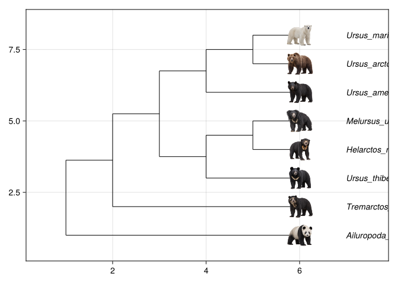

```julia
phylogeny_figaxplt.figure
```

## 5 Customizing the `ImageAnnotation` image annotations

The `ImageAnnotation` type specifies the image to draw and controls how that image appears at its node.

### 5.1 Other image sources

The first argument to `ImageAnnotation` is the image source. This source can be a path to a local image file or an HTTP or HTTPS URL. A URL must point directly to a raster image rather than to a web page that displays the image.

A single dictionary can contain both types of image source. The first 4 entries below use local files. The remaining 4 entries use images from Wikimedia Commons:

| Leaf label | Image source |
| --- | --- |
| `Melursus_ursinus` | [Sloth bear](https://commons.wikimedia.org/wiki/File:Sloth_Bear_Washington_DC.JPG) |
| `Ursus_americanus` | American black bear |
| `Ursus_arctos` | Brown bear |
| `Ursus_maritimus` | [Polar bear](https://commons.wikimedia.org/wiki/File:Polar_Bear_AdF.jpg) |

Before reusing an image, read its source page for its attribution and license.

We construct the dictionary as before, but pass either a local path or a URL as the source argument to each `ImageAnnotation`:

```julia
mixed_nodeimages_d = Dict(
    "Ailuropoda_melanoleuca" => ImageAnnotation(joinpath(image_dir, "Ailuropoda_melanoleuca.png")),
    "Tremarctos_ornatus" => ImageAnnotation(joinpath(image_dir, "Tremarctos_ornatus.png")),
    "Ursus_thibetanus" => ImageAnnotation(joinpath(image_dir, "Ursus_thibetanus.png")),
    "Helarctos_malayanus" => ImageAnnotation(joinpath(image_dir, "Helarctos_malayanus.png")),
    "Melursus_ursinus" => ImageAnnotation("https://thumb.wikimedia.org/wikipedia/commons/thumb/6/6c/Sloth_Bear_Washington_DC.JPG/960px-Sloth_Bear_Washington_DC.JPG"),
    "Ursus_americanus" => ImageAnnotation("https://thumb.wikimedia.org/wikipedia/commons/thumb/0/0f/Vancouver_Island_black_bear_%28Ursus_americanus_vancouveri%29_Tofino_4.jpg/960px-Vancouver_Island_black_bear_%28Ursus_americanus_vancouveri%29_Tofino_4.jpg"),
    "Ursus_arctos" => ImageAnnotation("https://thumb.wikimedia.org/wikipedia/commons/thumb/2/2a/Brown_bear_%28Ursus_arctos_arctos%29_running.jpg/960px-Brown_bear_%28Ursus_arctos_arctos%29_running.jpg"),
    "Ursus_maritimus" => ImageAnnotation("https://thumb.wikimedia.org/wikipedia/commons/thumb/3/3d/Polar_Bear_AdF.jpg/960px-Polar_Bear_AdF.jpg"),
)
```

**NoteInternet connection**

PhyloMakie downloads URL image sources when it first constructs the plot. Plotting images from URLs therefore requires an internet connection.

We pass the dictionary to `nodeimages` in the same way as before:

```julia
mixed_source_phylogeny_figaxplt = plot(
    phylogeny;
    nodeimages = mixed_nodeimages_d,
    leafoffset = 1.0,
    xlim = (0.5, 11.0),
    ylim = (0.25, 8.75),
)
```

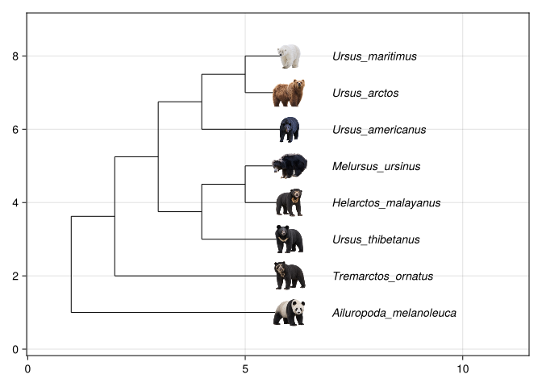

```julia
mixed_source_phylogeny_figaxplt.figure
```

### 5.2 Adjust image placement

By default, `ImageAnnotation` centers an image on its node. The `position` argument places the image to the left, right, above, or below its node. It also accepts `:upperleft`, `:upperright`, `:lowerleft`, and `:lowerright`.

Here, `position = :right` places the left edge of every image at its leaf node. The `offset` argument then adds 6 pixels of horizontal space between the node and the image:

```julia
positioned_nodeimages_d = Dict(
    "Ailuropoda_melanoleuca" => ImageAnnotation(
        joinpath(image_dir, "Ailuropoda_melanoleuca.png");
        position = :right,
        offset = (6, 0),
    ),
    "Tremarctos_ornatus" => ImageAnnotation(
        joinpath(image_dir, "Tremarctos_ornatus.png");
        position = :right,
        offset = (6, 0),
    ),
    "Ursus_thibetanus" => ImageAnnotation(
        joinpath(image_dir, "Ursus_thibetanus.png");
        position = :right,
        offset = (6, 0),
    ),
    "Helarctos_malayanus" => ImageAnnotation(
        joinpath(image_dir, "Helarctos_malayanus.png");
        position = :right,
        offset = (6, 0),
    ),
    "Melursus_ursinus" => ImageAnnotation(
        joinpath(image_dir, "Melursus_ursinus.png");
        position = :right,
        offset = (6, 0),
    ),
    "Ursus_americanus" => ImageAnnotation(
        joinpath(image_dir, "Ursus_americanus.png");
        position = :right,
        offset = (6, 0),
    ),
    "Ursus_arctos" => ImageAnnotation(
        joinpath(image_dir, "Ursus_arctos.png");
        position = :right,
        offset = (6, 0),
    ),
    "Ursus_maritimus" => ImageAnnotation(
        joinpath(image_dir, "Ursus_maritimus.png");
        position = :right,
        offset = (6, 0),
    ),
)
```

A small `leafoffset` places the node labels inside the images:

```julia
close_labels_figaxplt = plot(
    phylogeny;
    nodeimages = positioned_nodeimages_d,
    leafoffset = 0.1,
    xlim = (0.5, 11.0),
    ylim = (0.25, 8.75),
)
```

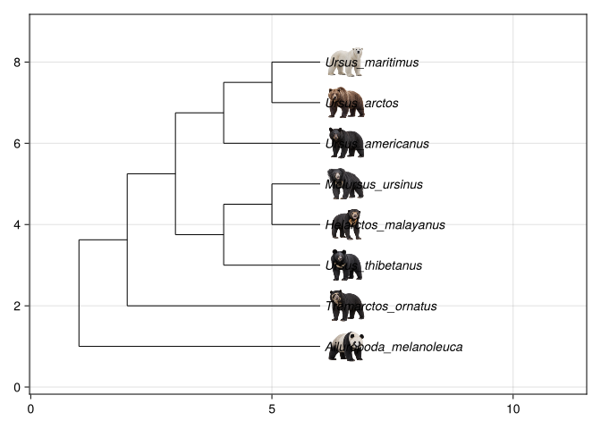

```julia
close_labels_figaxplt.figure
```

The image and node-label arguments control different parts of the plot:

- `position = :right` places the left edge of each image at its node.
- `offset = (6, 0)` moves the image 6 pixels to the right of its node.
- `leafoffset = 0.1` places each leaf label 0.1 x-axis data units to the right of its node.

To move the labels without moving the images, we increase `leafoffset`. We also set `xlim` and `ylim` to reserve space around the images and labels:

```julia
adjusted_phylogeny_figaxplt = plot(
    phylogeny;
    nodeimages = positioned_nodeimages_d,
    leafoffset = 1.2,
    xlim = (0.5, 11.0),
    ylim = (0.25, 8.75),
)
```

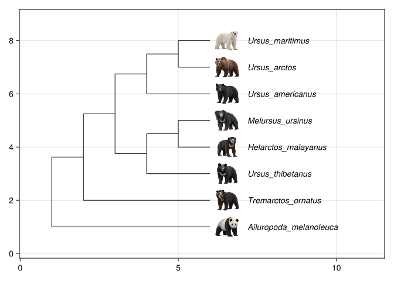

```julia
adjusted_phylogeny_figaxplt.figure
```

### 5.3 Other adjustments

Other `ImageAnnotation` arguments control the image’s size, aspect ratio, and alignment:

- `height` sets the full rendered height of the image.
- `scale` multiplies the value given by `height`.
- `size_space = :data` measures `height` in y-axis data units, while `size_space = :pixel` measures it in pixels.
- `aspect = :preserve` retains the image’s aspect ratio, while `aspect = :stretch` stretches the image into a square.
- `align` provides precise control over the point in the image that is aligned with the node.

In this example, a `height` of `0.55` leaves more space between images on adjacent leaf rows:

```julia
smaller_nodeimages_d = Dict(
    "Ailuropoda_melanoleuca" => ImageAnnotation(
        joinpath(image_dir, "Ailuropoda_melanoleuca.png");
        position = :right,
        height = 0.55,
        offset = (6, 0),
    ),
    "Tremarctos_ornatus" => ImageAnnotation(
        joinpath(image_dir, "Tremarctos_ornatus.png");
        position = :right,
        height = 0.55,
        offset = (6, 0),
    ),
    "Ursus_thibetanus" => ImageAnnotation(
        joinpath(image_dir, "Ursus_thibetanus.png");
        position = :right,
        height = 0.55,
        offset = (6, 0),
    ),
    "Helarctos_malayanus" => ImageAnnotation(
        joinpath(image_dir, "Helarctos_malayanus.png");
        position = :right,
        height = 0.55,
        offset = (6, 0),
    ),
    "Melursus_ursinus" => ImageAnnotation(
        joinpath(image_dir, "Melursus_ursinus.png");
        position = :right,
        height = 0.55,
        offset = (6, 0),
    ),
    "Ursus_americanus" => ImageAnnotation(
        joinpath(image_dir, "Ursus_americanus.png");
        position = :right,
        height = 0.55,
        offset = (6, 0),
    ),
    "Ursus_arctos" => ImageAnnotation(
        joinpath(image_dir, "Ursus_arctos.png");
        position = :right,
        height = 0.55,
        offset = (6, 0),
    ),
    "Ursus_maritimus" => ImageAnnotation(
        joinpath(image_dir, "Ursus_maritimus.png");
        position = :right,
        height = 0.55,
        offset = (6, 0),
    ),
)
```

```julia
smaller_phylogeny_figaxplt = plot(
    phylogeny;
    nodeimages = smaller_nodeimages_d,
    leafoffset = 1.0,
    xlim = (0.5, 11.0),
    ylim = (0.25, 8.75),
)
```

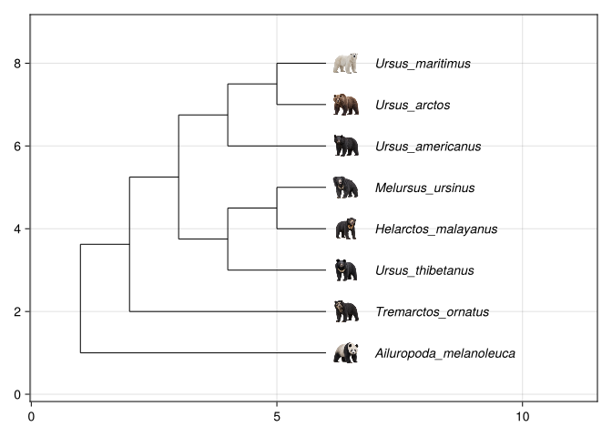

```julia
smaller_phylogeny_figaxplt.figure
```

## 6 Advanced workflows

The previous examples spell out each download and dictionary entry. When the same operation applies to a collection, `map` can express that operation once.

We first collect the remote image URLs as strings. We then use `map` with an anonymous function to download each image. `Downloads.download` returns the local path that it created, so `local_image_paths` is a collection of local file paths in the same order as `remote_image_urls`:

```julia
using Downloads

remote_image_urls = [
    "https://thumb.wikimedia.org/wikipedia/commons/thumb/6/6c/Sloth_Bear_Washington_DC.JPG/960px-Sloth_Bear_Washington_DC.JPG",
    "https://thumb.wikimedia.org/wikipedia/commons/thumb/0/0f/Vancouver_Island_black_bear_%28Ursus_americanus_vancouveri%29_Tofino_4.jpg/960px-Vancouver_Island_black_bear_%28Ursus_americanus_vancouveri%29_Tofino_4.jpg",
    "https://thumb.wikimedia.org/wikipedia/commons/thumb/2/2a/Brown_bear_%28Ursus_arctos_arctos%29_running.jpg/960px-Brown_bear_%28Ursus_arctos_arctos%29_running.jpg",
    "https://thumb.wikimedia.org/wikipedia/commons/thumb/3/3d/Polar_Bear_AdF.jpg/960px-Polar_Bear_AdF.jpg",
]

local_image_paths = map(
    url -> Downloads.download(url),
    remote_image_urls,
)
```

A second `map` applies an anonymous function to corresponding elements from `node_labels` and `local_image_paths`. The function returns `label => ImageAnnotation(path)` pairs, and `Dict` collects those pairs into the mapping accepted by the `nodeimages` keyword:

```julia
node_labels = [
    "Melursus_ursinus",
    "Ursus_americanus",
    "Ursus_arctos",
    "Ursus_maritimus",
]

length(node_labels) == length(local_image_paths) ||
    throw(DimensionMismatch("Each node label requires 1 image path."))

mapped_nodeimages_d = Dict(
    map(
        (label, path) -> label => ImageAnnotation(path),
        node_labels,
        local_image_paths,
    ),
)
```

The 2 collections must have the same length and matching order. Each label must also exactly match the corresponding node label in the phylogeny. Temporary download paths suit immediate use in the current workflow. Supply a destination path to `Downloads.download` when the files must persist at known locations.

## 7 Exercises

**Exercise 1**

**Adjust the image size and label position**

1. Change every image height from `0.55` to `0.5`.
2. Plot the phylogeny with `leafoffset` values of `0.5`, `0.8`, and `1.2`.
3. Identify the smallest value that prevents the labels from overlapping the images.
4. Adjust `xlim` if any label extends beyond the right edge of the plot.

**Exercise 2**

**Change image positions**

1. Place the giant panda image above its node with `position = :above`.
2. Place the polar bear image below its node with `position = :below`.
3. Adjust the 2 values in `offset` to add space between each image and its node.
4. Adjust `ylim` until every image remains inside the plot.

**Exercise 3**

**Replace an image URL**

1. Find another reusable raster image of 1 bear species.
2. Replace the corresponding source in `mixed_nodeimages_d` with its direct image URL.
3. Confirm that the dictionary key still exactly matches the leaf label.
4. Plot the phylogeny and record the image’s source, creator, and license.

## 8 Related recipes

- Downloading remote files
- Creating dictionary mappings

Back to top